# State of the Repository Report

2022-11-01 13:47:05

Rick Gilmore

# Purpose

This document summarizes information about Databrary’s holdings, partners, and citations. It draws upon datasets specific to these categories that are generated elsewhere.

# Community

The Databrary community consists of Institutions and their Authorized Investigators. Authorized Investigators may, in turn, grant access to Affiliates whose access they supervise.

## Growth

```r
new_stats <- databraryapi::get_db_stats()
new_stats$date <- lubridate::as_datetime(new_stats$date)

new_stats <- new_stats %>%
  dplyr::select(date, institutions, investigators, affiliates) %>%
  dplyr::mutate(date = lubridate::as_datetime(date))
if (purrr::is_empty(new_stats)) {
  stop("Unable to retrieve new statistics from Databrary.")
}
```

```r
if (params$from_gs) {
  db <- googlesheets::gs_title('Databrary-analytics')

  old_stats <- db %>%
    googlesheets::gs_read(ws = 'institutions-investigators')
} else {
  old_stats <- readr::read_csv("csv/institutions-investigators.csv", show_col_types = FALSE)
}
old_stats <- old_stats %>%
  dplyr::mutate(., date = lubridate::as_datetime(date))
```

```r
 # initialize updated_stats
updated_stats <- old_stats
if (as.logical(params$update_stats)) {
  next_entry <- dim(updated_stats)[1] + 1
  updated_stats[next_entry, ] = NA

  # fill with new data
  # updated_stats$date[next_entry] <- new_stats$date
  # updated_stats$institutions[next_entry] <- new_stats$investigators
  # updated_stats$investigators[next_entry] <- new_stats$investigators
  # updated_stats$affiliates[next_entry] <- new_stats$affiliates
  updated_stats[next_entry, ] <- new_stats
}

# Calculate change
n_rows <- dim(updated_stats)[1]

delta_investigators <- updated_stats$investigators[n_rows] - updated_stats$investigators[n_rows - 1]

delta_institutions <- updated_stats$institutions[n_rows] - updated_stats$institutions[n_rows - 1]

# filter NAs
updated_stats <- updated_stats %>%
  dplyr::filter(., !is.na(affiliates),
         !is.na(investigators),
         !is.na(affiliates),
         !is.na(date))
```

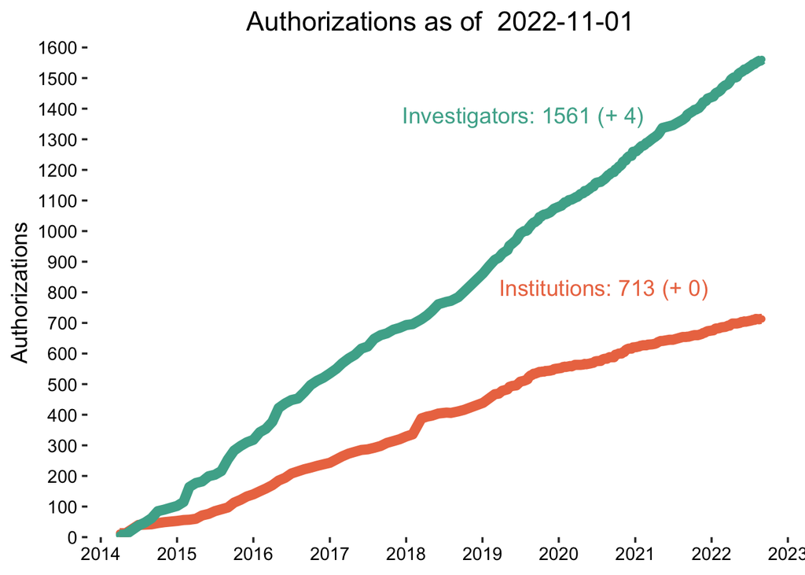

```r
# Create a tidy form for plotting both institutions and investigators and affiliates
gathered_stats <- updated_stats %>%
  tidyr::gather(., key = "type", value = "count", -date) %>%
  dplyr::mutate(date = lubridate::as_date(date)) %>%
  dplyr::select(date, count, type) %>%
  dplyr::filter(type %in% c('institutions', 'investigators')) %>%
  dplyr::filter(!is.na(count))

# Plot
users_plot <- gathered_stats %>%
  ggplot(., aes(
    x = date,
    y = count,
    color = type,
    group = type
  )) +
  scale_x_date(date_labels = "%Y", date_breaks = '1 year') +
  geom_point() +
  geom_line(size = ln_size) +
  scale_colour_manual(values = c(color_orange, color_teal)) +
  ggtitle(paste("Authorizations as of ", Sys.Date())) +
  ylab("Authorizations") +
  databrary_theme +
  scale_y_continuous(breaks = seq(0, plyr::round_any(max(
    gathered_stats$count
  ), 100, ceiling), 100), expand = c(0, 0)) +
  coord_cartesian(ylim = c(0, plyr::round_any(max(
    gathered_stats$count
  ), 100, ceiling)))

cowplot::ggdraw(users_plot) +
  cowplot::draw_label(paste0(
    "Investigators: ", updated_stats$investigators[n_rows],
    " (+ ", delta_investigators, ")"), colour = color_teal, .65, .8) +
  cowplot::draw_label(paste0(
    "Institutions: ", updated_stats$institutions[n_rows],
    " (+ ", delta_institutions, ")"), colour = color_orange, .75, .5)
```

```r
if (as.logical(params$update_gs)) {
  db <- db %>%
    gs_add_row(ws = 'institutions-investigators',
               input = new_stats)
  message("'update_gs' parameter is 'TRUE', so Google Sheet data will be updated.")
} else {
  message("'update_gs' parameter is 'FALSE', so Google Sheet data unmodified.")
}
```

```r
if (as.logical(params$update_csv)) {
  if (!purrr::is_empty(updated_stats)) {
  readr::write_csv(updated_stats, "csv/institutions-investigators.csv")
  message("Updated 'csv/institutions-investigators.csv'.")
  } else {
    message("No new institutions or investigator data to write.")
  }
}
```

## Map

```r
# Load saved file
inst_df <- readr::read_csv("../institutions-investigators/csv/institutions.csv", show_col_types = FALSE)
```

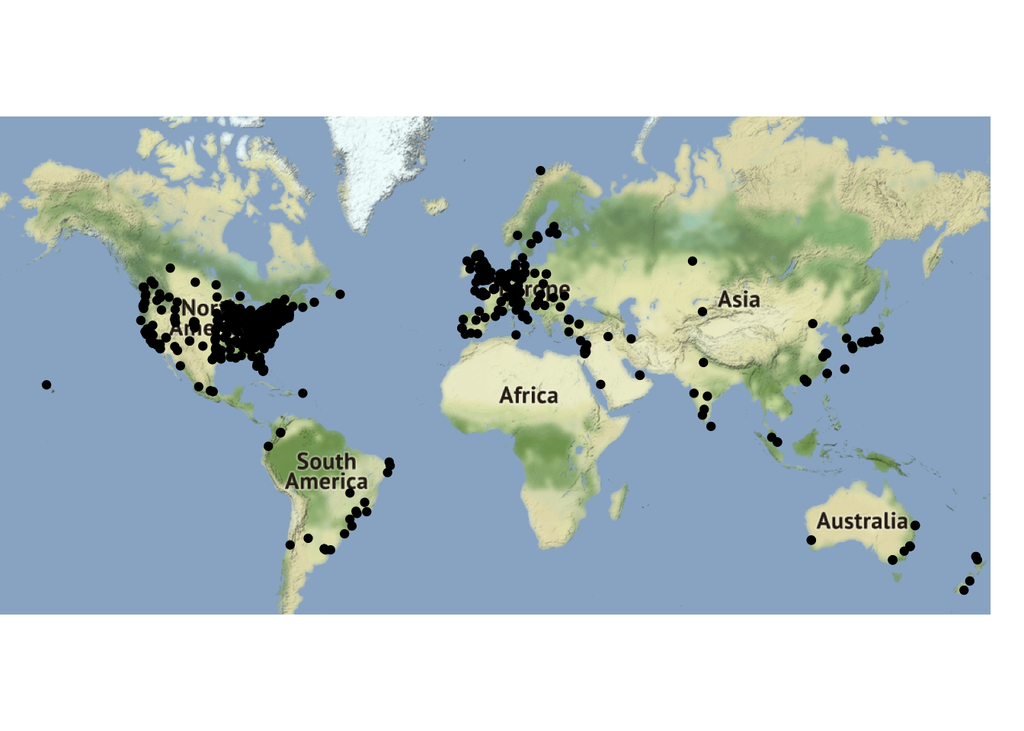

```r
ggmap::qmplot(lon, lat,
              data = inst_df,
              geom = "point")
```

## Investigators by institution

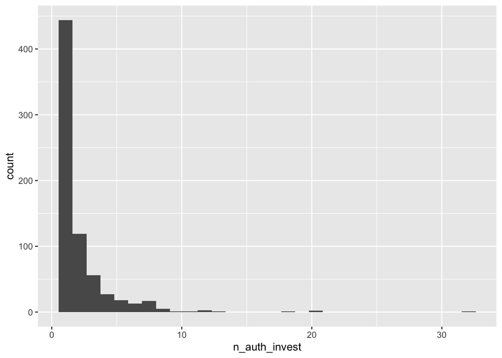

```r
with_ais <- inst_df %>%
  dplyr::filter(., n_auth_invest > 0)

ggplot(with_ais) +
  aes(n_auth_invest) +
  geom_histogram()
```

```r
gte5_ais <- with_ais %>%
  dplyr::filter(., n_auth_invest >= 5) %>%
  dplyr::mutate(., db_url = paste0("https://nyu.databrary.org/party/", inst_id)) %>%
  dplyr::distinct(.)
```

## Institutions with >= 5 investigators

There are $n=$ 63 institutions with at least five Authorized (PI-level) Investigators. They are as follows:

```r
gte5_ais %>%
  dplyr::arrange(., desc(n_auth_invest)) %>%
  dplyr::select(., inst_id, inst_name, db_url, n_auth_invest) %>%
  dplyr::distinct(.) %>%
  kableExtra::kbl(.) %>%
  kableExtra::kable_styling(.) %>%
  kableExtra::scroll_box(., height = "400px")
```

| inst_id | inst_name | db_url | n_auth_invest |
| --- | --- | --- | --- |
| 8 | New York University (NYU) | https://nyu.databrary.org/party/8 | 32 |
| 12 | Pennsylvania State University, University Park | https://nyu.databrary.org/party/12 | 20 |
| 236 | University of Toronto | https://nyu.databrary.org/party/236 | 20 |
| 137 | University of Maryland, College Park | https://nyu.databrary.org/party/137 | 18 |
| 225 | University of Iowa | https://nyu.databrary.org/party/225 | 13 |
| 179 | Boston University | https://nyu.databrary.org/party/179 | 12 |
| 201 | Northwestern University | https://nyu.databrary.org/party/201 | 12 |
| 215 | University of British Columbia, Vancouver | https://nyu.databrary.org/party/215 | 12 |
| 43 | University of Wisconsin, Madison | https://nyu.databrary.org/party/43 | 11 |
| 44 | University of Michigan | https://nyu.databrary.org/party/44 | 10 |
| 54 | University of Virginia | https://nyu.databrary.org/party/54 | 9 |
| 171 | Stanford University | https://nyu.databrary.org/party/171 | 9 |
| 203 | Ohio State University | https://nyu.databrary.org/party/203 | 9 |
| 1505 | New York University, School of Medicine | https://nyu.databrary.org/party/1505 | 9 |
| 1817 | Leiden University | https://nyu.databrary.org/party/1817 | 9 |
| 57 | University of Texas at Austin | https://nyu.databrary.org/party/57 | 8 |
| 176 | Arizona State University | https://nyu.databrary.org/party/176 | 8 |
| 216 | University of California, Davis | https://nyu.databrary.org/party/216 | 8 |
| 217 | University of California, Los Angeles | https://nyu.databrary.org/party/217 | 8 |
| 931 | Radboud University | https://nyu.databrary.org/party/931 | 8 |
| 1068 | Purdue University | https://nyu.databrary.org/party/1068 | 8 |
| 2451 | University of Illinois at Urbana-Champaign | https://nyu.databrary.org/party/2451 | 8 |
| 51 | Rutgers University, Newark | https://nyu.databrary.org/party/51 | 7 |
| 55 | Indiana University | https://nyu.databrary.org/party/55 | 7 |
| 59 | University of Chicago | https://nyu.databrary.org/party/59 | 7 |
| 146 | Temple University | https://nyu.databrary.org/party/146 | 7 |
| 190 | Harvard University | https://nyu.databrary.org/party/190 | 7 |
| 199 | Northeastern University | https://nyu.databrary.org/party/199 | 7 |
| 220 | University of Connecticut | https://nyu.databrary.org/party/220 | 7 |
| 227 | University of Massachusetts, Amherst | https://nyu.databrary.org/party/227 | 7 |
| 1187 | University of North Carolina, Greensboro | https://nyu.databrary.org/party/1187 | 7 |
| 4305 | Nanyang Technological University | https://nyu.databrary.org/party/4305 | 7 |
| 119 | Vanderbilt University | https://nyu.databrary.org/party/119 | 6 |
| 134 | Yale University | https://nyu.databrary.org/party/134 | 6 |
| 142 | University of California, Riverside | https://nyu.databrary.org/party/142 | 6 |
| 166 | University of Oregon | https://nyu.databrary.org/party/166 | 6 |
| 186 | Emory University | https://nyu.databrary.org/party/186 | 6 |
| 391 | Michigan State University | https://nyu.databrary.org/party/391 | 6 |
| 1043 | Rochester Institute of Technology | https://nyu.databrary.org/party/1043 | 6 |
| 1055 | Oregon State University | https://nyu.databrary.org/party/1055 | 6 |
| 1364 | Princeton University | https://nyu.databrary.org/party/1364 | 6 |
| 1981 | Lancaster University | https://nyu.databrary.org/party/1981 | 6 |
| 2255 | University of Waterloo | https://nyu.databrary.org/party/2255 | 6 |
| 2376 | University of California, Irvine | https://nyu.databrary.org/party/2376 | 6 |
| 2452 | Cardiff University | https://nyu.databrary.org/party/2452 | 6 |
| 50 | Carnegie Mellon University (CMU) | https://nyu.databrary.org/party/50 | 5 |
| 52 | Rutgers University, New Brunswick | https://nyu.databrary.org/party/52 | 5 |
| 58 | McMaster University | https://nyu.databrary.org/party/58 | 5 |
| 112 | Brown University | https://nyu.databrary.org/party/112 | 5 |
| 113 | Tulane University | https://nyu.databrary.org/party/113 | 5 |
| 115 | Virginia Tech | https://nyu.databrary.org/party/115 | 5 |
| 157 | University of Pittsburgh | https://nyu.databrary.org/party/157 | 5 |
| 168 | University of Portsmouth | https://nyu.databrary.org/party/168 | 5 |
| 172 | College of Staten Island, CUNY | https://nyu.databrary.org/party/172 | 5 |
| 182 | Cornell University | https://nyu.databrary.org/party/182 | 5 |
| 193 | Johns Hopkins University | https://nyu.databrary.org/party/193 | 5 |
| 195 | Massachusetts Institute of Technology | https://nyu.databrary.org/party/195 | 5 |
| 213 | University of Arizona | https://nyu.databrary.org/party/213 | 5 |
| 228 | University of Minnesota | https://nyu.databrary.org/party/228 | 5 |
| 237 | University of Washington | https://nyu.databrary.org/party/237 | 5 |
| 281 | Utrecht University | https://nyu.databrary.org/party/281 | 5 |
| 977 | University of Pennsylvania | https://nyu.databrary.org/party/977 | 5 |
| 2282 | University of North Carolina, Chapel Hill | https://nyu.databrary.org/party/2282 | 5 |

## Investigators with >= 5 affiliates

```r
invest_df <- readr::read_csv("../institutions-investigators/csv/investigators.csv",
                      show_col_types = FALSE)

gte5_affils <- invest_df %>%
  dplyr::arrange(., ai_id, ai_last) %>%
  dplyr::filter(., n_affils >= 5)
```

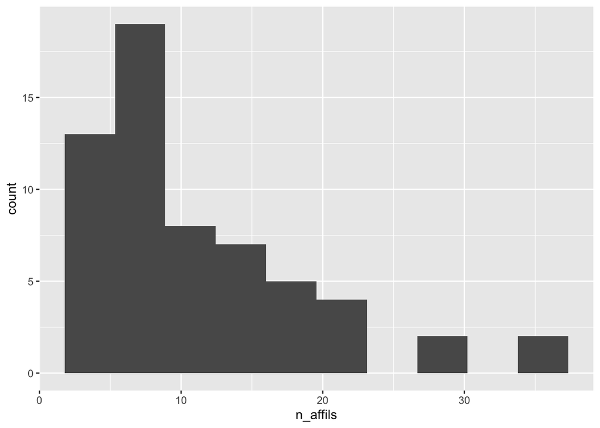

```r
ggplot(gte5_affils) +
  aes(n_affils) +
  geom_histogram(bins = 10)
```

```r
gte5_affils %>%
  dplyr::arrange(., desc(n_affils)) %>%
  dplyr::select(., ai_id, ai_last, ai_first, affiliation, ai_db_url, n_affils) %>%
  dplyr::group_by(., ai_id, ai_last) %>%
  dplyr::distinct(.) %>%
  kableExtra::kbl(.) %>%
  kableExtra::kable_styling(.) %>%
  kableExtra::scroll_box(., height = "400px")
```

| ai_id | ai_last | ai_first | affiliation | ai_db_url | n_affils |
| --- | --- | --- | --- | --- | --- |
| 5 | Adolph | Karen | New York University | https://nyu.databrary.org/party/5 | 37 |
| 531 | Goldstein | Thalia R. | George Mason University | https://nyu.databrary.org/party/531 | 28 |
| 3110 | Reich | Stephanie | University of California, Irvine | https://nyu.databrary.org/party/3110 | 27 |
| 538 | Oakes | Lisa | UC Davis | https://nyu.databrary.org/party/538 | 22 |
| 3044 | Cabrera | Natasha | University of Maryland College Park | https://nyu.databrary.org/party/3044 | 22 |
| 697 | Demir-Lira | O. Ece | University of Iowa | https://nyu.databrary.org/party/697 | 20 |
| 96 | Perez-Edgar | Koraly | The Pennsylvania State University | https://nyu.databrary.org/party/96 | 19 |
| 2382 | Berger | Sarah E | College of Staten Island, CUNY | https://nyu.databrary.org/party/2382 | 19 |
| 4945 | Lombardi | Doug | University of Maryland | https://nyu.databrary.org/party/4945 | 18 |
| 650 | Casasola | Marianella | Cornell University | https://nyu.databrary.org/party/650 | 17 |
| 1913 | Kucker | Sarah | Oklahoma State University | https://nyu.databrary.org/party/1913 | 15 |
| 70 | Messinger | Daniel | University of Miami | https://nyu.databrary.org/party/70 | 14 |
| 249 | Buss | Kristin A | The Pennsylvania State University | https://nyu.databrary.org/party/249 | 14 |
| 1117 | Jaswal | Vikram | University of Virginia | https://nyu.databrary.org/party/1117 | 14 |
| 562 | Weisberg | Deena Skolnick | Villanova University | https://nyu.databrary.org/party/562 | 13 |
| 5032 | Richert | Rebekah | University of California, Riverside | https://nyu.databrary.org/party/5032 | 13 |
| 1197 | Jirout | Jamie | University of Virginia | https://nyu.databrary.org/party/1197 | 12 |
| 82 | LoBue | Vanessa | Rutgers University | https://nyu.databrary.org/party/82 | 11 |
| 1612 | Corriveau | Kathleen | Boston University | https://nyu.databrary.org/party/1612 | 11 |
| 104 | Barr | Rachel | Georgetown University | https://nyu.databrary.org/party/104 | 10 |
| 32 | Karasik | Lana | CUNY | https://nyu.databrary.org/party/32 | 9 |
| 258 | Frank | Michael C. | Stanford University | https://nyu.databrary.org/party/258 | 9 |
| 2891 | Eisen | Sierra | Wesleyan University | https://nyu.databrary.org/party/2891 | 9 |
| 6 | Gilmore | Rick O. | The Pennsylvania State University | https://nyu.databrary.org/party/6 | 8 |
| 126 | Fausey | Caitlin M. | University of Oregon | https://nyu.databrary.org/party/126 | 8 |
| 5446 | Wagner | Nicholas | Boston University | https://nyu.databrary.org/party/5446 | 8 |
| 6754 | Wang | Jenny | Rutgers University | https://nyu.databrary.org/party/6754 | 8 |
| 1256 | Frank | Jennifer | The Pennsylvania State University | https://nyu.databrary.org/party/1256 | 7 |
| 2773 | Wojcik | Erica | Skidmore College | https://nyu.databrary.org/party/2773 | 7 |
| 8101 | Wilson | Rujuta | University of California, Los Angeles | https://nyu.databrary.org/party/8101 | 7 |
| 9020 | Saxbe | Darby | University of Southern California | https://nyu.databrary.org/party/9020 | 7 |
| 61 | Bergelson | Elika | Duke University | https://nyu.databrary.org/party/61 | 6 |
| 244 | Woodward | Amanda | University of Chicago | https://nyu.databrary.org/party/244 | 6 |
| 334 | Iverson | Jana | University of Pittsburgh | https://nyu.databrary.org/party/334 | 6 |
| 376 | Bahrick | Lorraine E. | Florida International University | https://nyu.databrary.org/party/376 | 6 |
| 1228 | Marshall | Peter | Temple University | https://nyu.databrary.org/party/1228 | 6 |
| 2176 | Harbourne | Regina | Duquesne University | https://nyu.databrary.org/party/2176 | 6 |
| 2581 | Camparo Avila | Daniel | Universidad de la República | https://nyu.databrary.org/party/2581 | 6 |
| 3743 | Ng | Florrie Fei-Yin | The Chinese University of Hong Kong | https://nyu.databrary.org/party/3743 | 6 |
| 5539 | Bauer | Patricia | Emory University | https://nyu.databrary.org/party/5539 | 6 |
| 5783 | Lucca | Kelsey | Arizona State University | https://nyu.databrary.org/party/5783 | 6 |
| 11 | Tamis-LeMonda | Catherine | New York University | https://nyu.databrary.org/party/11 | 5 |
| 99 | Frick | Janet | University of Georgia | https://nyu.databrary.org/party/99 | 5 |
| 277 | Rhodes | Marjorie | New York University | https://nyu.databrary.org/party/277 | 5 |
| 384 | Lee | Do Kyeong | California State University Fullerton | https://nyu.databrary.org/party/384 | 5 |
| 1371 | Lew-Williams | Casey | Princeton University | https://nyu.databrary.org/party/1371 | 5 |
| 2095 | Sullivan | Jessica | Skidmore College | https://nyu.databrary.org/party/2095 | 5 |
| 3517 | Curenton | Stephanie Michelle | Boston University | https://nyu.databrary.org/party/3517 | 5 |
| 4605 | Froemke | Robert | NYU School of Medicine | https://nyu.databrary.org/party/4605 | 5 |
| 5988 | Diosan | Laura | Babes Bolyai University, Faculty of Mathematics and Computer Science | https://nyu.databrary.org/party/5988 | 5 |
| 7217 | Sen | Hilal | MEF UNIVERSITY | https://nyu.databrary.org/party/7217 | 5 |
| 7537 | Zhao | Xin | East China Normal University | https://nyu.databrary.org/party/7537 | 5 |
| 8771 | Sandhofer | Catherine | UCLA | https://nyu.databrary.org/party/8771 | 5 |
| 9526 | Nelson | Nicole L | University of Adelaide | https://nyu.databrary.org/party/9526 | 5 |

# Volumes

A dataset or a collection of research materials is stored as a volume on Databrary.

## Growth

```r
new_stats <- databraryapi::get_db_stats()
new_stats$date <- lubridate::as_datetime(new_stats$date)
```

```r
if (params$from_gs) {
  db <- googlesheets::gs_title('Databrary-analytics')
  old_vols <- db %>%
    googlesheets::gs_read(ws = 'volumes-shared-unshared')
} else {
  old_vols <- readr::read_csv("csv/volumes-shared-unshared.csv")
}

if (purrr::is_empty(old_vols)) {
  stop("No old data loaded.")
}
```

```r
# Filter NAs
updated_vols <- old_vols %>%
  dplyr::filter(., !is.na(shared_volumes),
                !is.na(unshared_volumes),
                !is.na(date))

if (as.logical(params$update_stats)) {
  next_entry <- dim(updated_vols)[1] + 1
  updated_vols[next_entry,] = NA

  updated_vols$date[next_entry] <- new_stats$date
  if (is.null(new_stats$datasets_shared)) {
    new_stats$datasets_shared = 0
  }
  updated_vols$shared_volumes[next_entry] <- new_stats$datasets_shared
  updated_vols$unshared_volumes[next_entry] <-
    new_stats$datasets_total - new_stats$datasets_shared
}


# Calculate change
n_rows <- dim(updated_vols)[1]

delta_shared <- updated_vols$shared_volumes[n_rows] - updated_vols$shared_volumes[n_rows - 1]

delta_unshared <- updated_vols$unshared_volumes[n_rows] - updated_vols$unshared_volumes[n_rows - 1]

updated_vols <- updated_vols %>%
  dplyr::filter(., !is.na(shared_volumes),
                !is.na(unshared_volumes),
                !is.na(date))

gathered_vols <- updated_vols %>%
  tidyr::gather(., key = "type", value = "count", -date)
```

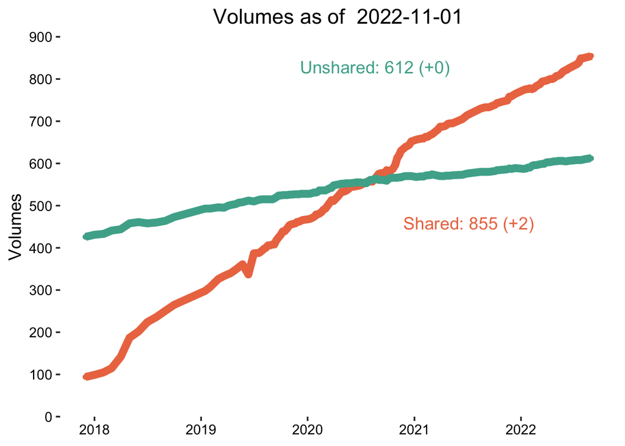

```r
# Plot
vols_plot <- gathered_vols %>%
  ggplot(., aes(
    x = date,
    y = count,
    color = type,
    group = type
  )) +
  geom_point() +
  geom_line(size = ln_size) +
  scale_colour_manual(values = c(color_orange, color_teal)) +
  ggtitle(paste("Volumes as of ", Sys.Date())) +
  ylab("Volumes") +
  databrary_theme +
  scale_y_continuous(breaks = seq(0, plyr::round_any(max(
    gathered_vols$count
  ),
  100, ceiling), 100),
  expand = c(0, 0)) +
  coord_cartesian(ylim = c(0, plyr::round_any(max(
    gathered_vols$count
  ),
  100, ceiling)))

cowplot::ggdraw(vols_plot) +
  cowplot::draw_label(
    paste0(
      "Unshared: ",
      updated_vols$unshared_volumes[n_rows],
      " (+",
      delta_unshared,
      ")"
    ),
    colour = color_teal,
    .6,
    .85
  ) +
  cowplot::draw_label(
    paste0(
      "Shared: ",
      updated_vols$shared_volumes[n_rows],
      " (+",
      delta_shared,
      ")"
    ),
    colour = color_orange,
    .75,
    .50
  )
```

```r
if (as.logical(params$update_gs)) {
  db <- db %>%
    gs_add_row(ws = 'volumes-shared-unshared', input = updated_vols)
} else {
  message("'update_gs' parameter is 'false', so Google Sheet data unmodified.")
}
```

```r
if (as.logical(params$update_csv)) {
  if (!is_empty(updated_vols)) {
    readr::write_csv(updated_vols, "csv/volumes-shared-unshared.csv")
    message("Updated 'csv/volumes-shared-unshared.csv'.")
  } else {
    message("No new volumes data to write.")
  }
}
```

## How shared

```r
get_volume_name <- function(vol_id) {
  vol_metadata <- databraryapi::list_volume_metadata(vol_id)
  if (!is.null(vol_metadata)) {
    as.character(vol_metadata$name)
  } else {
    NULL
  }
}

vols_sess_data <- readr::read_csv("../shared-volumes-sessions/csv/shared_volumes_sessions.csv", show_col_types = FALSE)

vols_dat <- vols_sess_data %>%
  # change variable names, create full_volume vs. overview_only
  dplyr::group_by(owner_ids.name, owner_ids.id) %>%
  dplyr::rename(investigator = owner_ids.name, party_id = owner_ids.id) %>%
  dplyr::mutate(shared_type = ifelse(sharing_level == "full", "full_volume", "overview_only")) %>%
  dplyr::select(investigator,
                party_id,
                vol_id,
                created_date,
                shared_type,
                n_sessions) %>%
  dplyr::mutate(url = paste0("https://nyu.databrary.org/party/", party_id)) %>%
  dplyr::group_by(investigator, url, shared_type) %>%
  # summarise by total shared volumes by type with session stats
  dplyr::summarise(
    n_vols = n(),
    tot_sess = sum(n_sessions),
    min_n_sess = min(n_sessions),
    max_n_sess = max(n_sessions)
  ) %>%
  dplyr::arrange(shared_type, desc(tot_sess))

unique_vols <- vols_sess_data %>%
  dplyr::rename(., investigator = owner_ids.name, party_id = owner_ids.id) %>%
  dplyr::mutate(.,
                shared_type = ifelse(sharing_level == "full",
                                     "full_volume", "overview_only")) %>%
  dplyr::mutate(., vol_url = paste0("https://nyu.databrary.org/volume/", vol_id)) %>%
  dplyr::group_by(., vol_id, vol_name, vol_url, created_date, shared_type, n_sessions) %>%
  dplyr::summarise(., n_owners = n())
```

There are $n=$ 860 total shared volumes on Databrary.

### Full volume

```r
unique_vols_full <- unique_vols %>%
  dplyr::filter(., shared_type == "full_volume")
```

Of these, there are $n=$ 286 volumes fully shared on Databrary.

```r
unique_vols_full %>%
  dplyr::arrange(., desc(n_sessions)) %>%
  knitr::kable(., "html") %>%
  kableExtra::kable_styling(.) %>%
  kableExtra::scroll_box(., height = "400px")
```

| vol_id | vol_name | vol_url | created_date | shared_type | n_sessions | n_owners |
| --- | --- | --- | --- | --- | --- | --- |
| 8 | Language, cognitive, and socio-emotional skills from 9 months until their transition to first grade in U.S. children from African-American, Dominican, Mexican, and Chinese backgrounds | https://nyu.databrary.org/volume/8 | 2013-10-14 15:54:05 | full_volume | 1351 | 1 |
| 564 | Head cameras on children aged 6 months through 31 months (SAYCam) | https://nyu.databrary.org/volume/564 | 2017-12-13 15:06:49 | full_volume | 467 | 5 |
| 90 | Word-minimality, Epenthesis and Coda Licensing in the Early Acquisition of English | https://nyu.databrary.org/volume/90 | 2014-11-20 17:48:20 | full_volume | 314 | 1 |
| 70 | Arnold Gesell’s Films of Infant and Child Development | https://nyu.databrary.org/volume/70 | 2014-10-17 00:10:02 | full_volume | 308 | 1 |
| 739 | Falls experienced by older adult residents in long-term care homes | https://nyu.databrary.org/volume/739 | 2018-08-17 04:32:07 | full_volume | 301 | 1 |
| 1304 | Using Storybooks to Teach Children About Illness Transmission and Promote Adaptive Health Behavior – A Pilot Study | https://nyu.databrary.org/volume/1304 | 2021-04-13 13:55:35 | full_volume | 301 | 3 |
| 11 | The Ties That Bind: Cradling in Tajikistan | https://nyu.databrary.org/volume/11 | 2014-03-25 02:04:43 | full_volume | 237 | 3 |
| 359 | Fostering Children’s Reasoning about Disagreements through an Inquiry-based Curriculum (time point 2) | https://nyu.databrary.org/volume/359 | 2017-05-22 15:44:50 | full_volume | 216 | 2 |
| 400 | Preschoolers’ extension and export of information from realistic and fantastical stories (Study 1) | https://nyu.databrary.org/volume/400 | 2017-06-14 13:43:08 | full_volume | 183 | 1 |
| 1042 | The impact factor in infant development: Falling like a baby | https://nyu.databrary.org/volume/1042 | 2020-01-14 15:52:20 | full_volume | 169 | 2 |
| 184 | Investigating the effectiveness of fantasy stories for teaching scientific principles (study 1) | https://nyu.databrary.org/volume/184 | 2015-11-09 19:01:20 | full_volume | 161 | 1 |
| 30 | The Child Affective Facial Expression (CAFE) set | https://nyu.databrary.org/volume/30 | 2014-07-23 15:57:05 | full_volume | 158 | 2 |
| 149 | Constructing Science: Connecting Causal Reasoning to Scientific Thinking in Young Children - which outcomes are science (chapter 7) | https://nyu.databrary.org/volume/149 | 2015-06-15 15:47:52 | full_volume | 155 | 1 |
| 139 | Fostering Children’s Reasoning about Disagreements through an Inquiry-based Curriculum (time point 1) | https://nyu.databrary.org/volume/139 | 2015-06-01 13:42:07 | full_volume | 142 | 2 |
| 5 | No bridge too high: Infants decide whether to cross based on the probability of falling not the severity of the potential fall | https://nyu.databrary.org/volume/5 | 2013-10-10 16:35:22 | full_volume | 135 | 1 |
| 1257 | INFORMS MKT | https://nyu.databrary.org/volume/1257 | 2020-12-09 19:53:11 | full_volume | 132 | 2 |
| 271 | Transition from crawling to walking and infants’ actions with objects and people | https://nyu.databrary.org/volume/271 | 2016-10-19 17:57:10 | full_volume | 126 | 3 |
| 563 | The Science of Everyday Play | https://nyu.databrary.org/volume/563 | 2017-12-12 13:29:26 | full_volume | 120 | 2 |
| 988 | Toy play: How children discover and implement the designed action of Duplo bricks | https://nyu.databrary.org/volume/988 | 2019-09-23 15:48:30 | full_volume | 119 | 4 |
| 207 | Of Blickets, Butterflies, and Baby Dinosaurs: Children’s Diagnostic Reasoning Across Domains (Study 1, blicket condition) | https://nyu.databrary.org/volume/207 | 2016-02-16 14:32:33 | full_volume | 118 | 1 |
| 445 | ManyBabies 1: bll-umanitoba | https://nyu.databrary.org/volume/445 | 2017-07-07 16:48:35 | full_volume | 118 | 2 |
| 897 | Learning the Designed Actions of Everyday Objects | https://nyu.databrary.org/volume/897 | 2019-05-03 17:38:55 | full_volume | 116 | 5 |
| 253 | Of Blickets, Butterflies, and Baby Dinosaurs: Children’s Diagnostic Reasoning Across Domains (Study 1, butterfly condition) | https://nyu.databrary.org/volume/253 | 2016-07-18 17:21:16 | full_volume | 115 | 2 |
| 89 | The cost of simplifying complex developmental phenomena: A new perspective on learning to walk | https://nyu.databrary.org/volume/89 | 2014-11-19 20:05:35 | full_volume | 114 | 1 |
| 150 | Preschoolers’ extension and export of information from realistic and fantastical stories (Study 2) | https://nyu.databrary.org/volume/150 | 2015-06-15 16:00:28 | full_volume | 111 | 1 |
| 308 | Investigating the effectiveness of fantasy stories for teaching scientific principles (study 2) | https://nyu.databrary.org/volume/308 | 2017-01-30 15:13:19 | full_volume | 110 | 1 |
| 114 | The development of tool use: Planning for end-state comfort. | https://nyu.databrary.org/volume/114 | 2015-03-13 17:49:55 | full_volume | 106 | 1 |
| 269 | Of Blickets, Butterflies, and Baby Dinosaurs: Children’s Diagnostic Reasoning Across Domains (Study 2) | https://nyu.databrary.org/volume/269 | 2016-10-14 13:48:41 | full_volume | 105 | 2 |
| 84 | Motor decisions are not black and white: Selecting actions in the “gray zone” | https://nyu.databrary.org/volume/84 | 2014-11-03 22:57:47 | full_volume | 104 | 1 |
| 1131 | Developmental changes in natural scene viewing in infancy | https://nyu.databrary.org/volume/1131 | 2020-05-06 17:52:06 | full_volume | 104 | 1 |

[output cut: 256 more lines]

### Overview only

```r
unique_vols_overview <- unique_vols %>%
  dplyr::filter(., shared_type == "overview_only")
```

There are $n=$ 574 volume overviews shared on Databrary.

```r
unique_vols_overview %>%
  dplyr::arrange(., desc(n_sessions)) %>%
  knitr::kable(., "html") %>%
  kableExtra::kable_styling(.) %>%
  kableExtra::scroll_box(., height = "400px")
```

| vol_id | vol_name | vol_url | created_date | shared_type | n_sessions | n_owners |
| --- | --- | --- | --- | --- | --- | --- |
| 1266 | Study 186 | https://nyu.databrary.org/volume/1266 | 2020-12-15 21:44:44 | overview_only | 941 | 1 |
| 777 | Mazira Project Developmental Assessments | https://nyu.databrary.org/volume/777 | 2018-10-02 22:39:36 | overview_only | 634 | 1 |
| 1455 | The role of gesture and mimicry for children’s pattern learning | https://nyu.databrary.org/volume/1455 | 2022-04-28 18:36:47 | overview_only | 515 | 1 |
| 212 | Toddlers Into Kindergarteners: Emotions Study (TIKES) | https://nyu.databrary.org/volume/212 | 2016-03-16 16:35:39 | overview_only | 405 | 1 |
| 1335 | CHUNKS | https://nyu.databrary.org/volume/1335 | 2021-06-29 19:16:18 | overview_only | 363 | 1 |
| 119 | A-n-T: Attention and Temperament in Infancy | https://nyu.databrary.org/volume/119 | 2015-04-16 20:13:10 | overview_only | 302 | 1 |
| 757 | Trade-Off Quality | https://nyu.databrary.org/volume/757 | 2018-09-05 19:23:52 | overview_only | 270 | 1 |
| 1195 | Study 105 | https://nyu.databrary.org/volume/1195 | 2020-10-14 19:01:34 | overview_only | 256 | 1 |
| 756 | Play Inclusion and Exclusion | https://nyu.databrary.org/volume/756 | 2018-09-05 14:30:39 | overview_only | 238 | 1 |
| 1083 | R’GOD - Wave 1 - Child & Parent | https://nyu.databrary.org/volume/1083 | 2020-03-14 23:07:35 | overview_only | 220 | 1 |
| 961 | Degu Repeat Reunion | https://nyu.databrary.org/volume/961 | 2019-08-14 16:40:12 | overview_only | 208 | 1 |
| 1241 | Everyday Learning Remote Study | https://nyu.databrary.org/volume/1241 | 2020-11-12 17:09:30 | overview_only | 206 | 9 |
| 717 | Self-directed learning by preschoolers in a naturalistic overhearing context | https://nyu.databrary.org/volume/717 | 2018-06-18 21:37:10 | overview_only | 198 | 2 |
| 1438 | Hong Kong Preschooler Study (52M Block Play) | https://nyu.databrary.org/volume/1438 | 2022-03-15 06:25:20 | overview_only | 180 | 1 |
| 764 | Fin Live In Person | https://nyu.databrary.org/volume/764 | 2018-09-18 18:45:29 | overview_only | 164 | 1 |
| 1348 | Archive - excluded and extra infant sessions collected in Pennsylvania 2009-2016 | https://nyu.databrary.org/volume/1348 | 2021-07-20 18:16:23 | overview_only | 162 | 1 |
| 870 | Nanit | https://nyu.databrary.org/volume/870 | 2019-03-20 16:34:03 | overview_only | 160 | 2 |
| 833 | Exploring the Individual Differences in Preschoolers’ Causal Stance | https://nyu.databrary.org/volume/833 | 2019-01-17 00:24:10 | overview_only | 158 | 1 |
| 849 | NoHelp Original | https://nyu.databrary.org/volume/849 | 2019-02-13 17:45:02 | overview_only | 154 | 1 |
| 1087 | STEM ID | https://nyu.databrary.org/volume/1087 | 2020-03-17 20:38:45 | overview_only | 152 | 1 |
| 726 | Do embodiment and fictionality affect young children’s learning? | https://nyu.databrary.org/volume/726 | 2018-07-03 20:18:11 | overview_only | 144 | 3 |
| 1316 | May I Grab Your Attention - A Lookit Study | https://nyu.databrary.org/volume/1316 | 2021-05-14 20:52:28 | overview_only | 142 | 1 |
| 808 | EyePatch Grasping | https://nyu.databrary.org/volume/808 | 2018-10-29 18:12:56 | overview_only | 136 | 1 |
| 1090 | R’GOD - Wave 3 - Child | https://nyu.databrary.org/volume/1090 | 2020-03-17 20:40:57 | overview_only | 129 | 1 |
| 1171 | Automated Video Interview Personality Assessments: Reliability, Validity, and Generalizability Investigations | https://nyu.databrary.org/volume/1171 | 2020-08-20 14:24:45 | overview_only | 129 | 1 |
| 963 | DARPA Containers | https://nyu.databrary.org/volume/963 | 2019-08-29 22:40:06 | overview_only | 128 | 2 |
| 1086 | R’GOD - Wave 2 - Child | https://nyu.databrary.org/volume/1086 | 2020-03-17 20:31:14 | overview_only | 128 | 1 |
| 1088 | R’GOD - Wave 4 - Child & Parent | https://nyu.databrary.org/volume/1088 | 2020-03-17 20:39:07 | overview_only | 128 | 1 |
| 989 | Containers | https://nyu.databrary.org/volume/989 | 2019-09-23 20:05:27 | overview_only | 127 | 2 |
| 1221 | Study 164 | https://nyu.databrary.org/volume/1221 | 2020-10-30 18:53:05 | overview_only | 122 | 1 |

[output cut: 544 more lines]

## Types of data

Databrary specializes in storing and sharing video and audio recordings, but the system supports the storage of other file types, see https://nyu.databrary.org/asset/formats. The following summarizes the composition of currently *shared* data:

```r
#quietly_read_csv <- safely(readr::read_csv)

if (dir.exists('../volume-assets/csv')) {
  csv_fns <- list.files('../volume-assets/csv', '\\.csv', full.names = TRUE)
  assets_df <- purrr::map_df(csv_fns, readr::read_csv, show_col_types = FALSE)
} else {
  stop(paste0('CSV directory not found: ', '../volume-assets/csv'))
}
```

### Data by volume

There are $n=$ 359 shared volumes with data/assets.

The following shows the number of shared volumes with a given data/asset type.

```r
assets_df %>%
  dplyr::group_by(asset_type) %>%
  dplyr::count(asset_type) %>%
  dplyr::arrange(., desc(n)) %>%
  kableExtra::kable(., format = 'html') %>%
  kableExtra::kable_styling(.) %>%
  kableExtra::scroll_box(., height = "400px")
```

| asset_type | n |
| --- | --- |
| MPEG-4 video | 291 |
| Portable document | 67 |
| Comma-separated values | 58 |
| Microsoft Word (Office Open XML) document | 44 |
| Microsoft Excel (Office Open XML) workbook | 43 |
| Datavyu | 42 |
| Plain text | 32 |
| JPEG image | 26 |
| Portable network graphics | 26 |
| MPEG-1 or MPEG-2 audio layer III | 19 |
| SPSS System File | 17 |
| Microsoft Word document | 8 |
| Microsoft PowerPoint (Office Open XML) presentation | 7 |
| Rich text format | 5 |
| ELAN - Linguistic Annotator | 3 |
| Microsoft Excel spreadsheet | 2 |
| Codes for the Human Analysis of Transcripts | 1 |
| Microsoft PowerPoint presentation | 1 |

### File-type focus

```r
assets_df %>%
  dplyr::group_by(asset_type) %>%
  dplyr::summarise(total_files = sum(n_files),
            total_size = sum(tot_size_gb),
            total_dur = sum(tot_dur_hrs)) %>%
  dplyr::arrange(., desc(total_files)) %>%
  dplyr::select(asset_type, total_files, total_size, total_dur) %>%
  kableExtra::kable(., format = 'html') %>%
  kableExtra::kable_styling(.) %>%
  kableExtra::scroll_box(., height = "400px")
```

| asset_type | total_files | total_size | total_dur |
| --- | --- | --- | --- |
| MPEG-4 video | 28927 | 1.072723e+04 | 9461.731 |
| Datavyu | 3519 | 1.606830e-02 | 0.000 |
| JPEG image | 2805 | 4.990314e+00 | 0.000 |
| ELAN - Linguistic Annotator | 1918 | 4.869400e-03 | 0.000 |
| Comma-separated values | 1913 | 3.214910e-01 | 0.000 |
| Plain text | 1748 | 1.039884e+02 | 0.000 |
| Portable network graphics | 1442 | 7.803730e-02 | 0.000 |
| MPEG-1 or MPEG-2 audio layer III | 1251 | 2.761787e+01 | 1951.321 |
| Portable document | 505 | 1.930056e+00 | 0.000 |
| Microsoft Excel (Office Open XML) workbook | 388 | 1.860380e-02 | 0.000 |
| Codes for the Human Analysis of Transcripts | 314 | 6.292870e-02 | 0.000 |
| Microsoft Word (Office Open XML) document | 267 | 3.021573e-01 | 0.000 |
| Rich text format | 109 | 1.248492e-01 | 0.000 |
| Microsoft Word document | 46 | 2.941720e-02 | 0.000 |
| SPSS System File | 35 | 1.431030e-02 | 0.000 |
| Microsoft PowerPoint (Office Open XML) presentation | 24 | 7.483950e-02 | 0.000 |
| Microsoft Excel spreadsheet | 15 | 1.501500e-03 | 0.000 |
| Microsoft PowerPoint presentation | 2 | 4.911000e-03 | 0.000 |

## Participant demographics

Databrary encourages users doing research with human participants to report demographic data in a structured format so that others may more easily find and reuse data relevant to their questions.

```r
load_demog_csvs <- function(dir = "../participant-demographics/csv") {
  if (!is.character(dir)) {
    stop("'dir' must be a string")
  }
  if (!dir.exists(dir)) {
    stop("'dir' does not exist.")
  }

  fl <- list.files(dir, "[0-9]{4}-sess-materials\\.csv$", full.names = TRUE)
  if (is.null(fl)) {
    stop(paste0("No csv files in ", dir, "."))
  }
  purrr::map_dfr(fl, read.csv, colClasses = "character")
}

demo_df <- load_demog_csvs()
```

### Overall

```r
demo_df <- demo_df %>%
  dplyr::filter(., session_date != "materials")
```

Databrary has demographic data for at least $n=$ 9876 individual participant sessions.

Not every volume reports the same collection of demographic variables, so the numbers will vary by variable.

```r
demo_df <- demo_df %>%
  dplyr::mutate(., vol_url = paste0("https://nyu.databrary.org/volume/", vol_id))
```

### Gender

The largest number of volumes report gender.

#### Volumes and sessions

```r
gender_df <- demo_df %>%
  dplyr::filter(., !is.na(participant_gender)) %>%
  dplyr::group_by(., vol_id, vol_url) %>%
  dplyr::summarize(., n_sessions = n()) %>%
  dplyr::ungroup(.) %>%
  dplyr::mutate(., n_vols_w_demo = n())

gender_df %>%
  dplyr::select(., vol_id, vol_url, n_sessions) %>%
  dplyr::arrange(., desc(n_sessions)) %>%
  knitr::kable(., "html") %>%
  kableExtra::kable_styling(.) %>%
  kableExtra::scroll_box(., height = "400px")
```

| vol_id | vol_url | n_sessions |
| --- | --- | --- |
| 8 | https://nyu.databrary.org/volume/8 | 1339 |
| 564 | https://nyu.databrary.org/volume/564 | 461 |
| 296 | https://nyu.databrary.org/volume/296 | 328 |
| 90 | https://nyu.databrary.org/volume/90 | 314 |
| 739 | https://nyu.databrary.org/volume/739 | 300 |
| 87 | https://nyu.databrary.org/volume/87 | 231 |
| 400 | https://nyu.databrary.org/volume/400 | 183 |
| 1042 | https://nyu.databrary.org/volume/1042 | 161 |
| 184 | https://nyu.databrary.org/volume/184 | 161 |
| 322 | https://nyu.databrary.org/volume/322 | 159 |
| 30 | https://nyu.databrary.org/volume/30 | 157 |
| 149 | https://nyu.databrary.org/volume/149 | 155 |
| 1075 | https://nyu.databrary.org/volume/1075 | 138 |
| 5 | https://nyu.databrary.org/volume/5 | 133 |
| 226 | https://nyu.databrary.org/volume/226 | 129 |
| 989 | https://nyu.databrary.org/volume/989 | 127 |
| 563 | https://nyu.databrary.org/volume/563 | 118 |
| 207 | https://nyu.databrary.org/volume/207 | 116 |
| 253 | https://nyu.databrary.org/volume/253 | 115 |
| 271 | https://nyu.databrary.org/volume/271 | 115 |
| 89 | https://nyu.databrary.org/volume/89 | 114 |
| 150 | https://nyu.databrary.org/volume/150 | 111 |
| 308 | https://nyu.databrary.org/volume/308 | 109 |
| 83 | https://nyu.databrary.org/volume/83 | 109 |
| 988 | https://nyu.databrary.org/volume/988 | 109 |
| 114 | https://nyu.databrary.org/volume/114 | 105 |
| 84 | https://nyu.databrary.org/volume/84 | 104 |
| 269 | https://nyu.databrary.org/volume/269 | 102 |
| 140 | https://nyu.databrary.org/volume/140 | 97 |
| 950 | https://nyu.databrary.org/volume/950 | 95 |

[output cut: 92 more lines]

There are $n=$ 122 volumes reporting `participant.gender`.

#### Number of participants

```r
xtabs(formula = ~ participant_gender, data = demo_df) %>%
  knitr::kable(., "html") %>%
  kableExtra::kable_styling(.) %>%
  kableExtra::scroll_box(., height = "400px")
```

| participant_gender | Freq |
| --- | --- |
| Female | 4399 |
| Male | 4413 |
| Non binary | 2 |
| Non-binary | 1 |
| Other | 1 |
| Unknown | 1 |
| Unknown or not reported | 1 |

### Race

#### Volumes and sessions

```r
race_df <- demo_df %>%
  dplyr::filter(., !is.na(participant_race)) %>%
  dplyr::group_by(., vol_id, vol_url) %>%
  dplyr::summarize(., n_sessions = n()) %>%
  dplyr::ungroup(.) %>%
  dplyr::mutate(., n_vols_w_demo = n())
```

There are $n=$ 108 volumes reporting `participant_race`.

```r
race_df %>%
  dplyr::select(., vol_id, vol_url, n_sessions) %>%
  dplyr::arrange(., desc(n_sessions)) %>%
  knitr::kable(., "html") %>%
  kableExtra::kable_styling(.) %>%
  kableExtra::scroll_box(., height = "400px")
```

| vol_id | vol_url | n_sessions |
| --- | --- | --- |
| 8 | https://nyu.databrary.org/volume/8 | 1339 |
| 564 | https://nyu.databrary.org/volume/564 | 461 |
| 296 | https://nyu.databrary.org/volume/296 | 328 |
| 87 | https://nyu.databrary.org/volume/87 | 231 |
| 400 | https://nyu.databrary.org/volume/400 | 177 |
| 322 | https://nyu.databrary.org/volume/322 | 159 |
| 184 | https://nyu.databrary.org/volume/184 | 157 |
| 149 | https://nyu.databrary.org/volume/149 | 155 |
| 30 | https://nyu.databrary.org/volume/30 | 134 |
| 5 | https://nyu.databrary.org/volume/5 | 133 |
| 226 | https://nyu.databrary.org/volume/226 | 129 |
| 989 | https://nyu.databrary.org/volume/989 | 127 |
| 1042 | https://nyu.databrary.org/volume/1042 | 122 |
| 563 | https://nyu.databrary.org/volume/563 | 118 |
| 207 | https://nyu.databrary.org/volume/207 | 114 |
| 89 | https://nyu.databrary.org/volume/89 | 114 |
| 271 | https://nyu.databrary.org/volume/271 | 113 |
| 253 | https://nyu.databrary.org/volume/253 | 112 |
| 150 | https://nyu.databrary.org/volume/150 | 110 |
| 83 | https://nyu.databrary.org/volume/83 | 109 |
| 988 | https://nyu.databrary.org/volume/988 | 109 |
| 308 | https://nyu.databrary.org/volume/308 | 107 |
| 114 | https://nyu.databrary.org/volume/114 | 105 |
| 269 | https://nyu.databrary.org/volume/269 | 105 |
| 84 | https://nyu.databrary.org/volume/84 | 104 |
| 140 | https://nyu.databrary.org/volume/140 | 97 |
| 950 | https://nyu.databrary.org/volume/950 | 94 |
| 162 | https://nyu.databrary.org/volume/162 | 93 |
| 152 | https://nyu.databrary.org/volume/152 | 84 |
| 1273 | https://nyu.databrary.org/volume/1273 | 82 |

[output cut: 78 more lines]

#### Number of participants

```r
xtabs(formula = ~ participant_race, data = demo_df) %>%
  knitr::kable(., "html") %>%
  kableExtra::kable_styling(.) %>%
  kableExtra::scroll_box(., height = "400px")
```

| participant_race | Freq |
| --- | --- |
| 1/2 White, 1/2 Asian | 1 |
| African American and White | 1 |
| American Indian or Alaska Native | 7 |
| Arab | 1 |
| Asian | 1190 |
| Asian and Hispanic or Latino | 1 |
| Asian and White | 1 |
| Biracial | 1 |
| Black or African American | 1155 |
| Black or African American White | 1 |
| Black/Mixed | 1 |
| Chose not to answer | 4 |
| Decline to State | 1 |
| Did Not Answer | 3 |
| European White | 38 |
| H | 7 |
| Half Asian | 1 |
| Hispanic/Mixed Race | 1 |
| Indian | 3 |
| Latino, Native American, white | 1 |
| Middle East | 1 |
| Mixed | 2 |
| More than one | 693 |
| Native Hawaiian or Other Pacific Islander | 1 |
| Nepall | 1 |
| Not reported | 2 |
| Not Reported | 2 |
| Other | 14 |
| Pacific Islander | 1 |
| South Asian | 14 |
| South East Asian/ East Asian | 1 |
| Unknown or not reported | 360 |
| White | 3900 |
| White & Mexican American | 1 |
| White and Afro LAtina | 2 |
| White and Asian | 6 |
| White, American Indian or Alaskan Native, and Hispanic or Latino | 1 |
| White/Asian | 1 |
| White/Mixed | 1 |
| White/Vietnamese | 1 |

### Ethnicity

#### Volumes and sessions

```r
ethnicity_df <- demo_df %>%
  dplyr::filter(., !is.na(participant_ethnicity)) %>%
  dplyr::group_by(., vol_id, vol_url) %>%
  dplyr::summarize(., n_sessions = n()) %>%
  dplyr::ungroup(.) %>%
  dplyr::mutate(., n_vols_w_demo = n())
```

```r
ethnicity_df %>%
  dplyr::select(., vol_id, vol_url, n_sessions) %>%
  dplyr::arrange(., desc(n_sessions)) %>%
  knitr::kable(., "html") %>%
  kableExtra::kable_styling(.) %>%
  kableExtra::scroll_box(., height = "400px")
```

| vol_id | vol_url | n_sessions |
| --- | --- | --- |
| 8 | https://nyu.databrary.org/volume/8 | 1339 |
| 564 | https://nyu.databrary.org/volume/564 | 461 |
| 296 | https://nyu.databrary.org/volume/296 | 328 |
| 87 | https://nyu.databrary.org/volume/87 | 231 |
| 322 | https://nyu.databrary.org/volume/322 | 159 |
| 184 | https://nyu.databrary.org/volume/184 | 158 |
| 1042 | https://nyu.databrary.org/volume/1042 | 155 |
| 400 | https://nyu.databrary.org/volume/400 | 151 |
| 5 | https://nyu.databrary.org/volume/5 | 133 |
| 226 | https://nyu.databrary.org/volume/226 | 129 |
| 989 | https://nyu.databrary.org/volume/989 | 121 |
| 563 | https://nyu.databrary.org/volume/563 | 118 |
| 253 | https://nyu.databrary.org/volume/253 | 114 |
| 89 | https://nyu.databrary.org/volume/89 | 114 |
| 207 | https://nyu.databrary.org/volume/207 | 113 |
| 271 | https://nyu.databrary.org/volume/271 | 111 |
| 83 | https://nyu.databrary.org/volume/83 | 109 |
| 308 | https://nyu.databrary.org/volume/308 | 108 |
| 114 | https://nyu.databrary.org/volume/114 | 105 |
| 269 | https://nyu.databrary.org/volume/269 | 105 |
| 988 | https://nyu.databrary.org/volume/988 | 105 |
| 84 | https://nyu.databrary.org/volume/84 | 104 |
| 140 | https://nyu.databrary.org/volume/140 | 97 |
| 162 | https://nyu.databrary.org/volume/162 | 93 |
| 484 | https://nyu.databrary.org/volume/484 | 91 |
| 152 | https://nyu.databrary.org/volume/152 | 84 |
| 1273 | https://nyu.databrary.org/volume/1273 | 82 |
| 150 | https://nyu.databrary.org/volume/150 | 81 |
| 950 | https://nyu.databrary.org/volume/950 | 80 |
| 434 | https://nyu.databrary.org/volume/434 | 79 |

[output cut: 77 more lines]

There are $n=$ 107 volumes reporting `participant_ethnicity`.

#### Number of participants

```r
xtabs(formula = ~ participant_ethnicity, data = demo_df) %>%
  # dplyr::arrange(., desc(Freq)) %>%
  knitr::kable(., "html") %>%
  kableExtra::kable_styling(.) %>%
  kableExtra::scroll_box(., height = "400px")
```

| participant_ethnicity | Freq |
| --- | --- |
| Asian | 1 |
| Chinese | 223 |
| Choose not to answer | 2 |
| Chose not to answer | 3 |
| Chose Not to Disclose | 1 |
| Decline to State | 2 |
| did not answer | 1 |
| Did Not Answer | 3 |
| Dominican | 402 |
| Hispanic or Latino | 875 |
| Indigenous | 1 |
| Mexican | 364 |
| Not Hispanic or Latino | 4416 |
| Not indigenous | 2 |
| Not reported | 3 |
| Not Reported | 4 |
| Refused | 1 |
| Unknown or not reported | 837 |

## Tags & keywords

```r
tags <- readr::read_csv("../tags-keywords/csv/databrary-tags.csv", show_col_types = FALSE)
```

### Histogram of tags/volume

```r
vols_without_tags <- tags %>%
  dplyr::filter(., is.na(tags))

vols_with_tags <- tags %>%
  dplyr::filter(., !is.na(tags)) %>%
  dplyr::group_by(., vol_id) %>%
  dplyr::summarise(., n_tags = n())
```

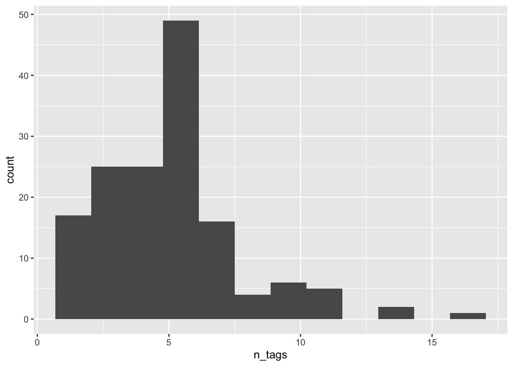

```r
vols_with_tags %>%
  ggplot2::ggplot(.) +
  aes(n_tags) +
  geom_histogram(bins = 12)
```

### Unique tags

```r
unique_tags <- tags %>%
  dplyr::select(., tags, weight) %>%
  dplyr::filter(., !is.na(tags)) %>%
  dplyr::group_by(., tags) %>%
  dplyr::summarise(., n_vols_using = n(), weight_sum = sum(weight)) %>%
  dplyr::arrange(., desc(n_vols_using))
```

There are $n=$ 400 unique tags.

```r
unique_tags %>%
  knitr::kable(., "html") %>%
  kableExtra::kable_styling()
```

| tags | n_vols_using | weight_sum |
| --- | --- | --- |
| infants | 40 | 45 |
| children | 22 | 23 |
| eye-tracking | 15 | 17 |
| stimuli | 15 | 16 |
| materials | 13 | 13 |
| motion | 12 | 12 |
| faces | 11 | 18 |
| locomotion | 10 | 10 |
| motor development | 10 | 11 |
| perception | 10 | 12 |
| adult | 9 | 9 |
| language development | 9 | 9 |
| parent-child interaction | 9 | 10 |
| play | 9 | 9 |
| optic flow | 8 | 8 |
| coding | 7 | 7 |
| cognitive development | 6 | 9 |
| attention | 5 | 5 |
| cognitive | 5 | 7 |
| eeg | 5 | 5 |
| face processing | 5 | 5 |
| learning | 5 | 5 |
| manuals | 5 | 5 |
| numerical cognition | 5 | 7 |
| visual attention | 5 | 7 |
| walking | 5 | 5 |
| cross-cultural research | 4 | 5 |
| culture | 4 | 6 |
| data | 4 | 4 |
| eye tracking | 4 | 4 |

[output cut: 370 more lines]

### Word cloud

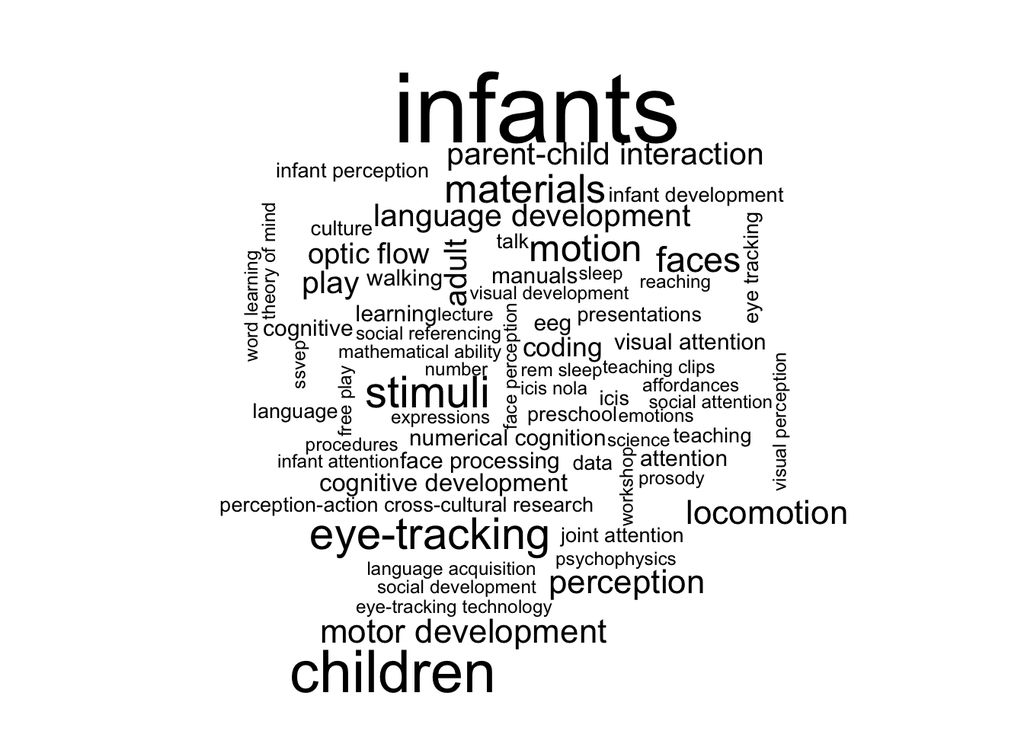

```r
wordcloud::wordcloud(words = unique_tags$tags,
                     freq = unique_tags$n_vols_using)
```

# Citations

We mine the Google Scholar database to estimate the number of citations to Databrary or Datavyu.

```r
if (params$from_gs) {
  db <- googlesheets::gs_title('Databrary-analytics')

  old_citations <- db %>%
    googlesheets::gs_read(ws = 'citations-monthly')
} else {
  old_citations <- readr::read_csv("csv/citations-monthly.csv")
}

old_citations <- old_citations %>%
  dplyr::mutate(date = lubridate::as_date(date))
```

```r
# Get citation counts from Google Scholar
get_citation_stats <- function(project = 'databrary') {
  if (project %in% c('databrary', 'Databrary')) {
    url <-
      'https://scholar.google.com/scholar?hl=en&as_sdt=1%2C39&as_vis=1&q=%22databrary%22+%22Databrary%22&btnG='
  } else if (project %in% c('datavyu', 'Datavyu')) {
    url <-
      'https://scholar.google.com/scholar?hl=en&as_sdt=1%2C39&as_vis=1&q=%22Datavyu%22+%22datavyu%22&btnG='
  }

  r <- httr::GET(url = url)
  if (httr::status_code(r) == 200) {
    content <- httr::content(r, 'text')
  } else {
    message(paste0('Download Failed, HTTP status ', httr::status_code(r)))
  }

  n_results <-
    stringr::str_match(content, pattern = "About ([0-9]+)")[2]
  if (is.null(n_results)) {
    message(paste0('Unable to parse results from search.'))
    return(NULL)
  } else {
    return(as.numeric(n_results))
  }
}

databrary_cites <- get_citation_stats('databrary')
datavyu_cites <- get_citation_stats('datavyu')
```

```r
# Merge old with new
citations <- old_citations
if (as.logical(params$update_stats)) {
  next_value <- dim(old_citations)[1] + 1
  citations[next_value, ] <- NA

  citations$date[next_value] <- lubridate::as_date(Sys.Date())
  citations$databrary_citations[next_value] <- databrary_cites
  citations$datavyu_citations[next_value] <- datavyu_cites
}

# Calculate change
n_rows <- dim(citations)[1]
delta_db_cites <-
  citations$databrary_citations[n_rows] - citations$databrary_citations[n_rows - 1]
delta_dv_cites <-
  citations$datavyu_citations[n_rows] - citations$datavyu_citations[n_rows - 1]

# Filter NAs
citations <- citations %>%
  dplyr::filter(.,!is.na(date),
                !is.na(databrary_citations),
                !is.na(datavyu_citations))
```

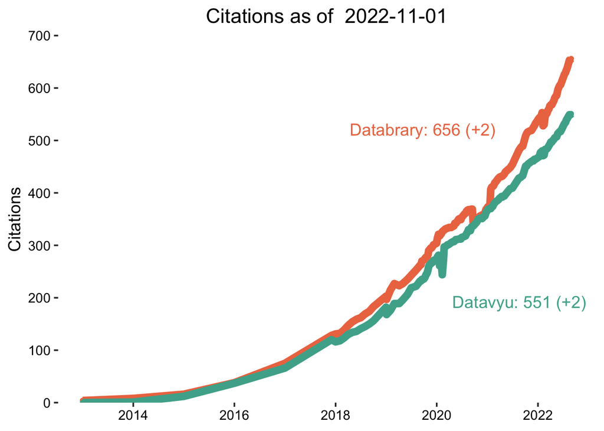

```r
gathered_citations <- citations %>%
  tidyr::gather(., key = "type", value = "count", -date)

# Plot
citations_plot <-
  gathered_citations %>%
  ggplot(., aes(
    x = date,
    y = count,
    color = type,
    group = type
  )) +
  geom_point() +
  geom_line(size = ln_size) +
  scale_colour_manual(values = c(color_orange, color_teal)) +
  ggtitle(paste("Citations as of ", Sys.Date())) +
  ylab("Citations") +
  databrary_theme +
  scale_y_continuous(breaks = seq(0, plyr::round_any(
    max(gathered_citations$count),
    100, ceiling
  ), 100),
  expand = c(0, 0)) +
  coord_cartesian(ylim = c(0, plyr::round_any(
    max(gathered_citations$count), 100, ceiling
  )))

cowplot::ggdraw(citations_plot) +
  cowplot::draw_label(
    paste0(
      "Datavyu: ",
      citations$datavyu_citations[n_rows],
      " (+",
      delta_dv_cites,
      ")"
    ),
    colour = color_teal,
    .86,
    .3
  ) +
  cowplot::draw_label(
    paste0(
      "Databrary: ",
      citations$databrary_citations[n_rows],
      " (+",
      delta_db_cites,
      ")"
    ),
    colour = color_orange,
    .7,
    .7
  )
```

Google Scholar Citations for [Databrary](https://scholar.google.com/scholar?hl=en&as_sdt=0%2C39&q=%22databrary%22+%22Databrary%22&oq=) and [Datavyu](https://scholar.google.com/scholar?hl=en&as_sdt=1%2C39&as_vis=1&q=%22Datavyu%22+%22datavyu%22&btnG=).

```r
if (as.logical(params$update_gs)) {
  new_data <- citations$date[next_value,]
  db <- db %>%
    googlesheets::gs_add_row(ws = 'citations-monthly',
                             input = new_data)
  message("'update_gs' parameter is 'TRUE', so Google Sheet data will be updated.")
} else {
  message("'update_gs' parameter is 'FALSE', so Google Sheet data unmodified.")
}
```

```r
if (as.logical(params$update_csv)) {
  if (!(is_empty(citations))) {
    readr::write_csv(citations, "csv/citations-monthly.csv")
    message("Updated 'csv/citations-monthly.csv'.")
  } else {
    message("No new citations data to write.")
  }
}
```